# Biostatistical Computing, PHC 6068

Optimization

Zhiguang Huo (Caleb)

Monday Nov 2, 2020

# Outline

- Univariate Optimization
  - Optimization in R
  - Gradient decent
  - Newton’s method
- Multivariate Optimization
  - Gradient decent
  - Newton’s method
  - Coordinate decent

# Optimization

- In mathematics, “optimization” or “mathematical programming” refers to the selection of a best element (with regard to some criterion) from some set of available alternatives.
- A typical optimization problem usually consists of maximizing or minimizing a real function (objective function) by systematically choosing input values under certain constraint.
- “Convex programming” studies the case when the objective function is convex (minimization) or concave (maximization) and the constraint set is convex.

# Convex function

Convex function properties:

- Second derivative always greater than 0
- Tangent lines always underestimate the function
- $\forall t \in (0,1)$, $tf(a) + (1 - t)f(b) > f(ta + (1 - t)b)$

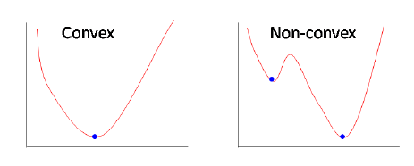

- Convex optimization always leads to a global minimizer
- Non-convex optimization usually leads to a local minimizer

# Optimization functions in R

- optimize(): One dimensional optimization, no gradient or Hessian
- optim(): General purpose optimization, five possible methods, gradient optional
- constrOptim(): Minimization of a function subject to linear inequality constraints, gradient optional
- nlm(): Non-linear minimization, can optionally include the gradient and hessian of the function as attributes of the objective function
- nlminb(): Minimization using PORT routines, can optionally include the gradient and Hessian of the objective function as additional arguments

# Univariate optimization example

Suppose our objective function is
$$f(x) = e^x + x^4$$
What is the minimum value of $f(x)$, what is the correponding $x$?

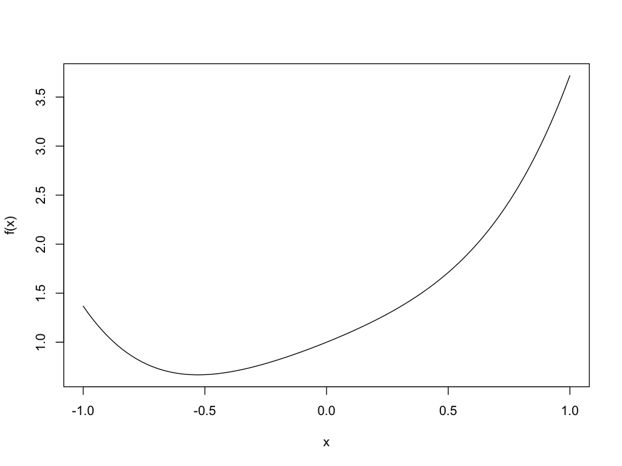

```r
f <- function(x) exp(x) + x^4
curve(f, from = -1, to = 1)
```

# Use R optimize() function to perform the optimization

```r
f <- function(x) exp(x) + x^4
xmin <- optimize(f, interval = c(-10, 10))
xmin
```

```
## $minimum
## [1] -0.5282468
##
## $objective
## [1] 0.6675038
```

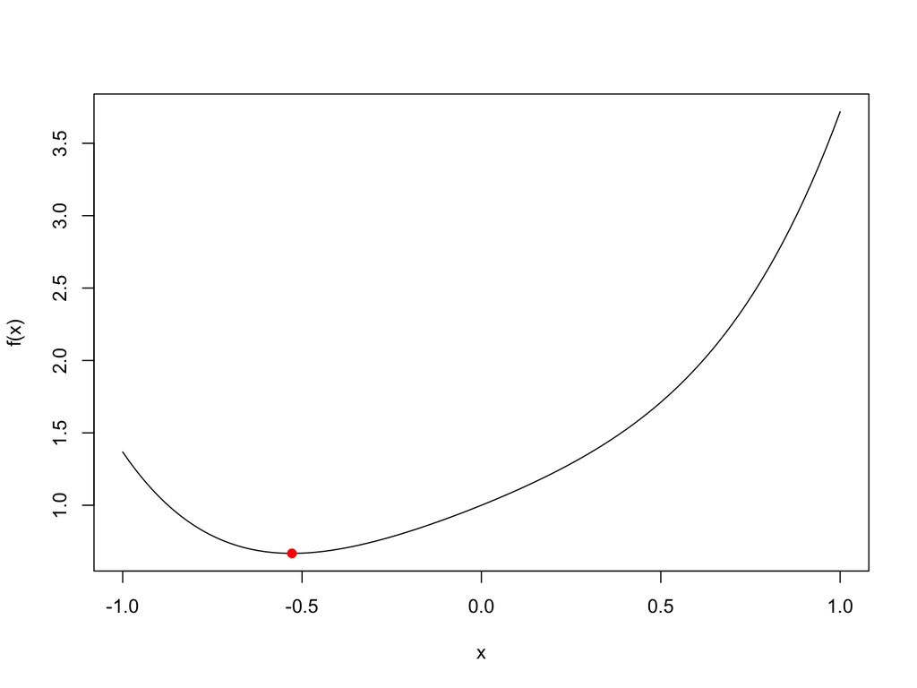

```r
curve(f, from = -1, to = 1)
points(xmin$minimum, xmin$objective, col="red", pch=19)
```

# Gradient decent

- Consider an unconstrained minimization of $f$, we want to find $x^*$ such that
  $$f(x^*) = \min_{x\in \mathbb{R}} f(x)$$
- Another way to formulate the problem is to find $x^*$ such that
  $$x^* = \arg_{x\in \mathbb{R}} \min f(x)$$

**Gradient decent**: choose initial $x^{(0)} \in \mathbb{R}$, repeat:
$$x^{(k)} = x^{(k - 1)} - t\times f'(x^{(k - 1)}), k = 1,2,3,\ldots$$

- Until $|x^{(k)} - x^{(k - 1)}| < \varepsilon$, (e.g. $\varepsilon = 10^{-6}$).
- $f'(x^{(k - 1)})$ is the gradient (derivative of $f$) evaluated at $x^{(k - 1)}$.
- $t$ is a step size for gradient decent procedure.

# Interpretation

- At each iteration $k$, consider Taylor expansion at $x^{(k - 1)}$:
  $$f(y) = f(x^{(k - 1)}) + f'(x^{(k - 1)}) \times (y - x^{(k - 1)}) + \frac{1}{2} f''(x^{(k - 1)}) (y - x^{(k - 1)})^2 + \ldots$$
- Quadratic approximation:
  - Replacing $f''(x^{(k - 1)})$ with $\frac{1}{t}$
  - Ingore higher order terms

$$f(y) \approx f(x^{(k - 1)}) + f'(x^{(k - 1)}) \times (y - x^{(k - 1)}) + \frac{1}{2t} (y - x^{(k - 1)})^2$$

- Minimizing the quadratic approximation.
  $$x^{(k)} = \arg_y \min f(y)$$
  - Set $f'(x^{(k)}) = 0 \Leftrightarrow f'(x^{(k - 1)}) + \frac{1}{t} (x^{(k)} - x^{(k - 1)}) = 0 \Leftrightarrow x^{(k)} = x^{(k - 1)} - t\times f'(x^{(k - 1)})$
  - This is exactly the same as the gradient decent procedure.

# Visual interpretation

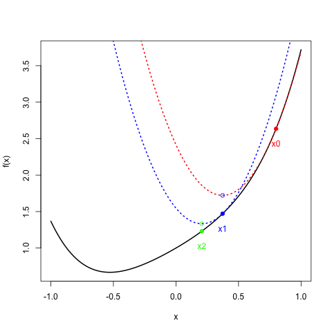

- iterate 1: $x^{(1)} = x^{(0)} - t\times f'(x^{(0)})$
  - quadratic approximation at $x_0$,
  - minimizer of the quadratic approximation is $x_1$
- iterate 2: $x^{(2)} = x^{(1)} - t\times f'(x^{(1)})$
  - quadratic approximation at $x_1$,
  - minimizer of the quadratic approximation is $x_2$
- …

# Gradient decent on our motivating example

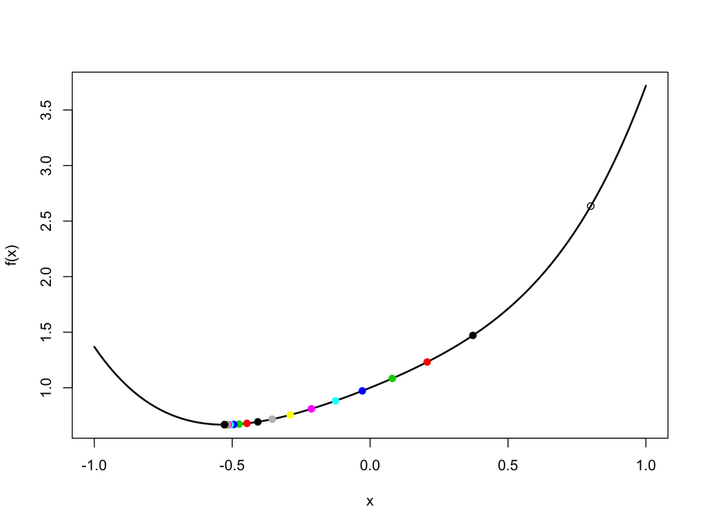

```r
f <- function(x) exp(x) + x^4 ## original function
g <- function(x) exp(x) + 4 * x^3 ## gradient function
curve(f, from = -1, to = 1, lwd=2) ## visualize the objective function

x <- x0 <- 0.8; x_old <- 0; t <- 0.1; k <- 0; error <- 1e-6
trace <- x
points(x0, f(x0), col=1, pch=1)

while(abs(x - x_old) > error){ ## there is a scale issue.
  ## E.g., if x = 1e-7, x_old = 1e-6, relative change is large, absolute change is small
  ## We can monitor abs(x - x_old) / (abs(x) + abs(x_old))
  k <- k + 1
  x_old <- x
  x <- x_old - t*g(x_old)
  trace <- c(trace, x) ## collecting results
  points(x, f(x), col=k, pch=19)
}
```

```r
trace_grad <- trace
print(trace)
```

```
##  [1]  0.80000000  0.37264591  0.20678990  0.08028037 -0.02828567
##  [6] -0.12548768 -0.21290391 -0.28986708 -0.35496119 -0.40719158
## [11] -0.44673749 -0.47504573 -0.49435026 -0.50702281 -0.51511484
## [16] -0.52018513 -0.52332289 -0.52524940 -0.52642641 -0.52714331
## [21] -0.52757914 -0.52784381 -0.52800441 -0.52810183 -0.52816091
## [26] -0.52819673 -0.52821844 -0.52823161 -0.52823959 -0.52824443
## [31] -0.52824736 -0.52824914 -0.52825021 -0.52825087
```

# A non-convex example

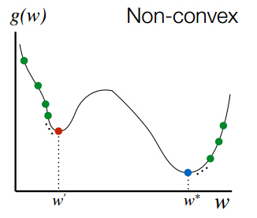

- If the objective function has multiple local minimums.
- Gradient will still work, but may fall into a local minimum (might be global minimum).

# Discussion, will gradient decent algorithm always converge?

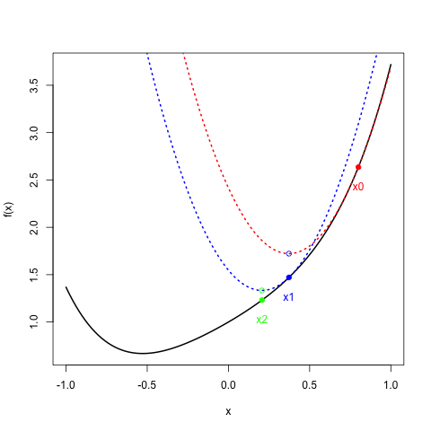

# No, see the example

- Minimize $f(x) = x^2$
- Initial point $x_0 = 1$
- stepsize $t = 1.1$

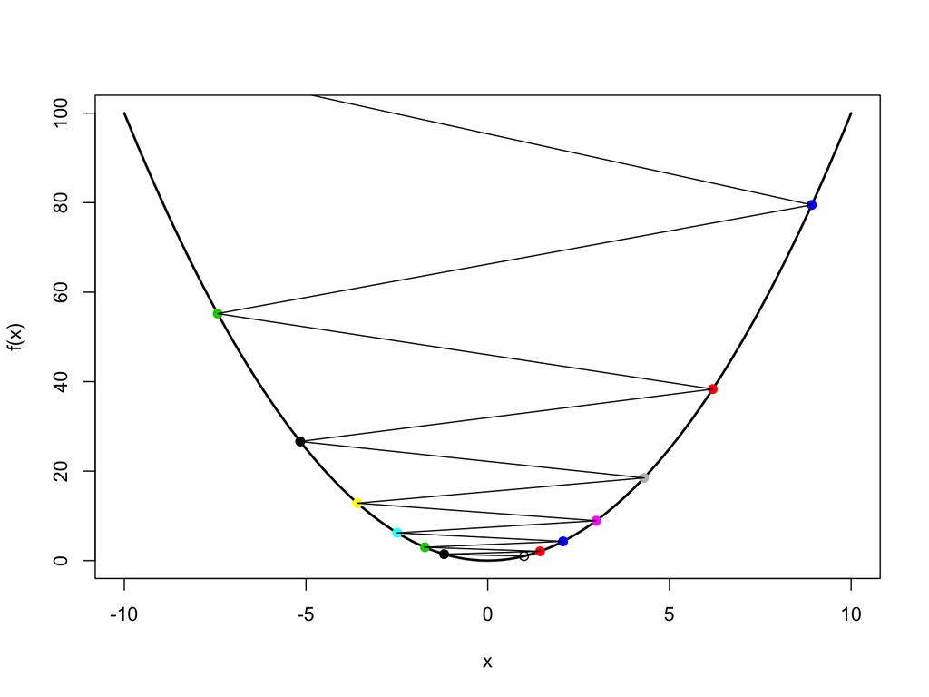

```r
f <- function(x) x^2 ## original function
g <- function(x) 2*x ## gradient function
curve(f, from = -10, to = 10, lwd=2) ## visualize the objective function

x <- x0 <- 1; x_old <- 0; t <- 1.1; k <- 0; error <- 1e-6
trace <- x
points(x0, f(x0), col=1, pch=1)

while(abs(x - x_old) > error & k < 30){ ## there is a scale issue.
  ## E.g., if x = 1e-7, x_old = 1e-6, relative change is large, absolute change is small
  ## We can monitor abs(x - x_old) / (abs(x) + abs(x_old))
  k <- k + 1
  x_old <- x
  x <- x_old - t*g(x_old)
  trace <- c(trace, x) ## collecting results
  points(x, f(x), col=k, pch=19)
  segments(x0=x, y0 = f(x), x1 = x_old, y1 = f(x_old))
}
```

```r
print(trace)
```

```
##  [1]    1.000000   -1.200000    1.440000   -1.728000    2.073600
##  [6]   -2.488320    2.985984   -3.583181    4.299817   -5.159780
## [11]    6.191736   -7.430084    8.916100  -10.699321   12.839185
## [16]  -15.407022   18.488426  -22.186111   26.623333  -31.948000
## [21]   38.337600  -46.005120   55.206144  -66.247373   79.496847
## [26]  -95.396217  114.475460 -137.370552  164.844662 -197.813595
## [31]  237.376314
```

# Change to another stepsize

- Minimize $f(x) = x^2$
- Initial point $x_0 = 1$
- stepsize $t = 0.2$

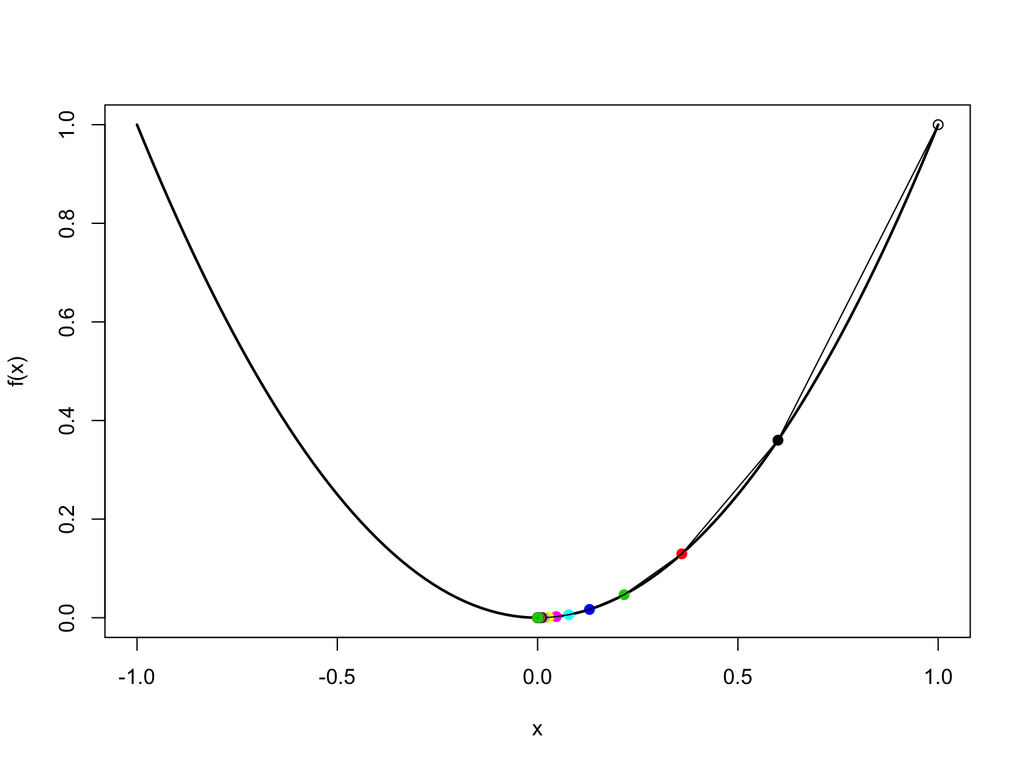

```r
f <- function(x) x^2 ## original function
g <- function(x) 2*x ## gradient function
curve(f, from = -1, to = 1, lwd=2) ## visualize the objective function

x <- x0 <- 1; x_old <- 0; t <- 0.2; k <- 0; error <- 1e-6
trace <- x
points(x0, f(x0), col=1, pch=1)

while(abs(x - x_old) > error & k < 30){
  k <- k + 1
  x_old <- x
  x <- x_old - t*g(x_old)
  trace <- c(trace, x) ## collecting results
  points(x, f(x), col=k, pch=19)
  segments(x0=x, y0 = f(x), x1 = x_old, y1 = f(x_old))
}
```

```r
print(trace)
```

```
##  [1] 1.000000e+00 6.000000e-01 3.600000e-01 2.160000e-01 1.296000e-01
##  [6] 7.776000e-02 4.665600e-02 2.799360e-02 1.679616e-02 1.007770e-02
## [11] 6.046618e-03 3.627971e-03 2.176782e-03 1.306069e-03 7.836416e-04
## [16] 4.701850e-04 2.821110e-04 1.692666e-04 1.015600e-04 6.093597e-05
## [21] 3.656158e-05 2.193695e-05 1.316217e-05 7.897302e-06 4.738381e-06
## [26] 2.843029e-06 1.705817e-06 1.023490e-06
```

# Change to another stepsize

- Minimize $f(x) = x^2$
- Initial point $x_0 = 1$
- stepsize $t = 0.01$

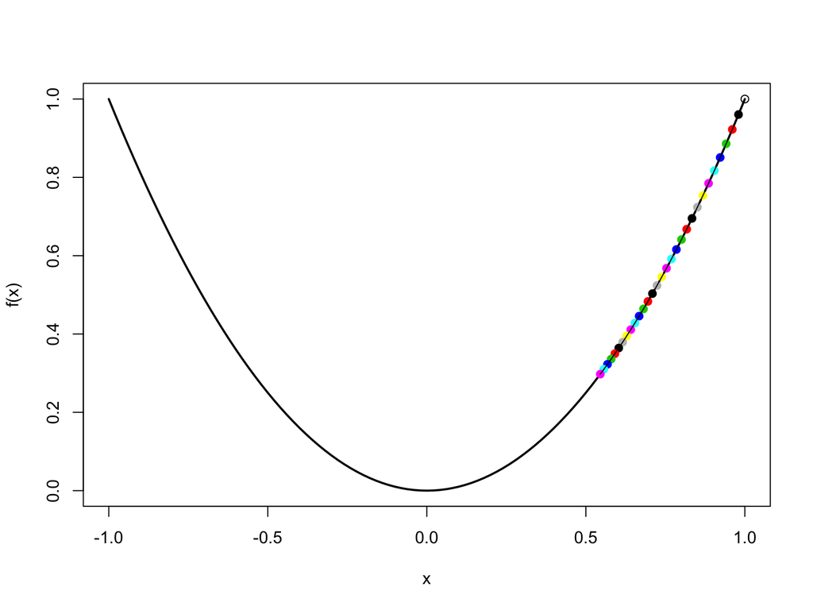

```r
f <- function(x) x^2 ## original function
g <- function(x) 2*x ## gradient function
curve(f, from = -1, to = 1, lwd=2) ## visualize the objective function

x <- x0 <- 1; x_old <- 0; t <- 0.01; k <- 0; error <- 1e-6
trace <- x
points(x0, f(x0), col=1, pch=1)

while(abs(x - x_old) > error & k < 30){
  k <- k + 1
  x_old <- x
  x <- x_old - t*g(x_old)
  trace <- c(trace, x) ## collecting results
  points(x, f(x), col=k, pch=19)
  segments(x0=x, y0 = f(x), x1 = x_old, y1 = f(x_old))
}
```

```r
print(trace)
```

```
##  [1] 1.0000000 0.9800000 0.9604000 0.9411920 0.9223682 0.9039208 0.8858424
##  [8] 0.8681255 0.8507630 0.8337478 0.8170728 0.8007314 0.7847167 0.7690224
## [15] 0.7536419 0.7385691 0.7237977 0.7093218 0.6951353 0.6812326 0.6676080
## [22] 0.6542558 0.6411707 0.6283473 0.6157803 0.6034647 0.5913954 0.5795675
## [29] 0.5679762 0.5566167 0.5454843
```

# How to select stepsize $t$, backtracking line search

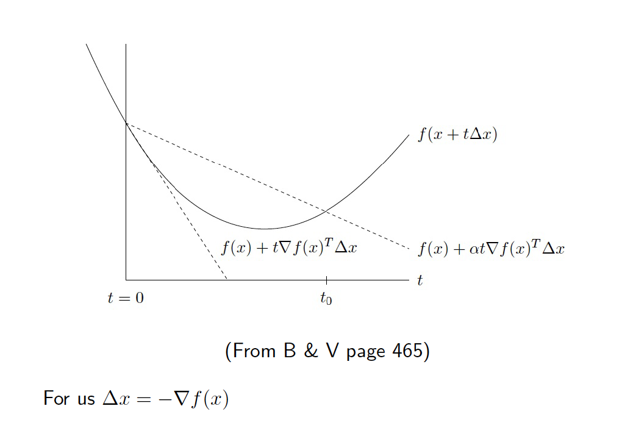

# How to select stepsize $t$, backtracking line search

- Linear approximation (first order Taylor expansion) at the current point $x$.
  $$f(x + t\Delta x) = f(x) + tf'(x)\Delta x$$
- Decrease the slope of the approximation by $\alpha$

$$f(x) + t\alpha f'(x)\Delta x$$

- A sufficient condition for a proposed $t$ to guarantee **decent** (decrease objective function):
  $$f(x + t\Delta x) < f(x) + t\alpha f'(x)\Delta x$$
- Plugin $\Delta x = -f'(x)$
  $$f(x - tf'(x)) < f(x) - t\alpha (f'(x))^2$$

# Backtracking line search Algorithm

- Fix parameter $0 < \beta < 1$ and $0 < \alpha \le 1/2$
- At each gradient decent iteration, start with $t=1$, while
  $$f(x - t\times f'(x)) > f(x) - \alpha t \times (f'(x))^2$$
  Update $t = \beta t$
- When the above interation stops, use $t$ as the step size

**Note:** you may always want to initialize $t = 1$ before backtracking line search.

# Implementation of back-tracking for gradient decent on the motivating example

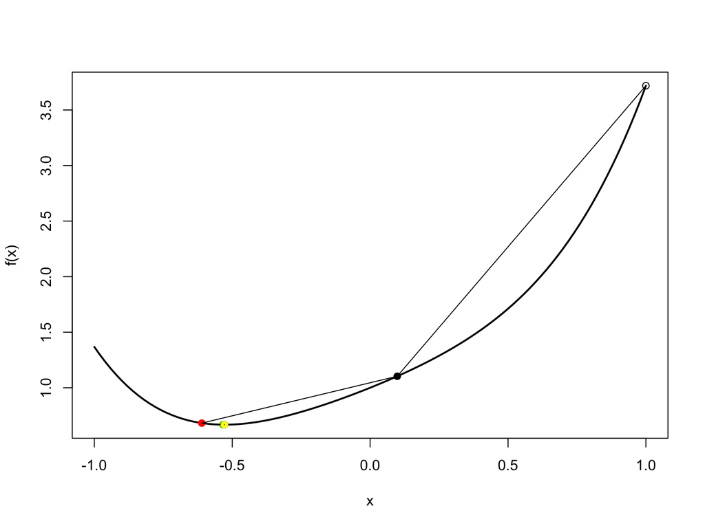

```r
f <- function(x) exp(x) + x^4 ## original function
g <- function(x) exp(x) + 4 * x^3 ## gradient function
curve(f, from = -1, to = 1, lwd=2) ## visualize the objective function

x <- x0 <- 1; x_old <- 0; t0 <- 1; k <- 0; error <- 1e-6; beta = 0.8; alpha <- 0.4
trace <- x
points(x0, f(x0), col=1, pch=1)

while(abs(x - x_old) > error & k < 30){
  k <- k + 1
  x_old <- x

  ## backtracking
  t <- t0
  while(f(x_old - t*g(x_old)) > f(x_old) - alpha * t * g(x_old)^2){
    t <- t * beta
  }

  x <- x_old - t*g(x_old)
  trace <- c(trace, x) ## collecting results
  points(x, f(x), col=k, pch=19)
  segments(x0=x, y0 = f(x), x1 = x_old, y1 = f(x_old))
}
```

```r
print(trace)
```

```
## [1]  1.00000000  0.09828748 -0.61024238 -0.53353118 -0.52803658 -0.52825877
## [7] -0.52825165 -0.52825188
```

# Exercise (will be on HW), solve for logistic regression

```r
library(ElemStatLearn)
data2 <- prostate[,c("svi", "lcavol")]
str(data2)
```

```
## 'data.frame':    97 obs. of  2 variables:
##  $ svi   : int  0 0 0 0 0 0 0 0 0 0 ...
##  $ lcavol: num  -0.58 -0.994 -0.511 -1.204 0.751 ...
```

- Y: svi, binary 0/1.
- X: lcavol, continuous.
- logistic regression

$$\log \frac{E(Y|x)}{1 - E(Y|x)} = \beta_0 + x\beta_1$$

# Exercise (will be on HW), solve for logistic regression

```r
glm_binomial_logit <- glm(svi ~ lcavol, data = prostate,  family = binomial())
summary(glm_binomial_logit)
```

```
##
## Call:
## glm(formula = svi ~ lcavol, family = binomial(), data = prostate)
##
## Deviance Residuals:
##      Min        1Q    Median        3Q       Max
## -1.79924  -0.48354  -0.21025  -0.04274   2.32135
##
## Coefficients:
##             Estimate Std. Error z value Pr(>|z|)
## (Intercept)  -5.0296     1.0429  -4.823 1.42e-06 ***
## lcavol        1.9798     0.4543   4.358 1.31e-05 ***
## ---
## Signif. codes:  0 '***' 0.001 '**' 0.01 '*' 0.05 '.' 0.1 ' ' 1
##
## (Dispersion parameter for binomial family taken to be 1)
##
##     Null deviance: 101.35  on 96  degrees of freedom
## Residual deviance:  64.14  on 95  degrees of freedom
## AIC: 68.14
##
## Number of Fisher Scoring iterations: 6
```

- We set $\beta_0 = -5.0296$.
- Try to optimize $\beta_1$, the coefficient for lcavol using gradient decent method
- compare with glm result.
- compare with the result using optimize() function.

# Exercise (will be on HW), some hints

- density function:
  $$f(y) = p(x)^y(1 - p(x))^{1 - y}$$
- likelihood function:
  $$L(\beta_0, \beta_1) = \prod_{i = 1}^n p(x_i)^{y_i}(1 - p(x_i))^{1 - y_i}$$
- logistic regression, logit link
  $$\log \frac{p(x)}{1 - p(x)} = \beta_0 + x\beta_1$$
- log likelihood function:

$\begin{aligned} l(\beta_0, \beta_1) &= \log\prod_{i = 1}^n p(x_i)^{y_i}(1 - p(x_i))^{(1 - y_i)} \\ & = \sum_{i=1}^n y_i \log p(x_i) + (1 - y_i) \log (1 - p(x_i)) \\ & = \sum_{i=1}^n \log (1 - p(x_i)) + \sum_{i=1}^n y_i \log \frac{p(x_i)}{1 - p(x_i)} \\ & = \sum_{i=1}^n -\log(1 + \exp(\beta_0 + x_i \beta_1)) + \sum_{i=1}^n y_i (\beta_0 + x_i\beta_1)\\ \end{aligned}$

# Newton’s method

- For unconstrained, smooth univariate convex optimization
  $$\min f(x)$$
  where $f$ is convex, twice differentable, $x \in \mathbb{R}$, $f \in \mathbb{R}$. For **gradient descent**, start with intial value $x^{(0)}$ and repeat the following $(k = 1,2,3,\ldots)$ until converge
  $$x^{(k)} = x^{(k - 1)} - t_k f'(x^{(k - 1)})$$
- For **Newton’s method**, start with intial value $x^{(0)}$ and repeat the following $(k = 1,2,3,\ldots)$ until converge
  $$x^{(k)} = x^{(k - 1)} - (f''(x^{(k - 1)}))^{-1} f'(x^{(k - 1)})$$
  Where $f''(x^{(k - 1)})$ is the second derivative of $f$ at $x^{(k - 1)}$. It is also refered as Hessian matrix for higher dimension (e.g. $x \in \mathbb{R}^p$)

# Newton’s method interpretation

- For gradient decent step at $x$, we minimize the quadratic approximation
  $$f(y) \approx f(x) + f'(x)(y - x) + \frac{1}{2t}(y - x)^2$$
  over $y$, which yield the update $x^{(k)} = x^{(k - 1)} - tf'(x^{(k-1)})$
- Newton’s method uses a better quadratic approximation:
  $$f(y) \approx f(x) + f'(x)(y - x) + \frac{1}{2}f''(x)(y - x)^2$$
  minimizing over $y$ yield $x^{(k)} = x^{(k - 1)} - (f''(x^{(k-1)}))^{-1}f'(x^{(k-1)})$

# Newton’s method on our motivating example

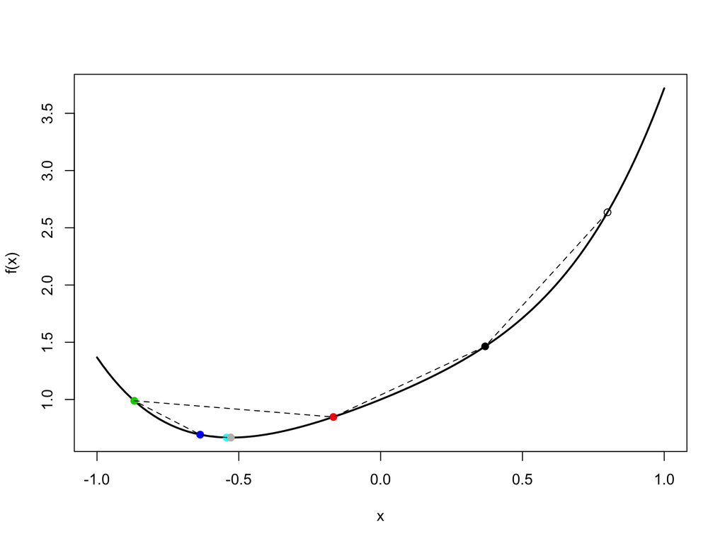

```r
f <- function(x) exp(x) + x^4 ## original function
g <- function(x) exp(x) + 4 * x^3 ## gradient function
h <- function(x) exp(x) + 12 * x^2 ## Hessian function
curve(f, from = -1, to = 1, lwd=2) ## visualize the objective function

x <- x0 <- 0.8; x_old <- 0; t <- 0.1; k <- 0; error <- 1e-6
trace <- x
points(x0, f(x0), col=1, pch=1)

while(abs(x - x_old) > error){
  k <- k + 1
  x_old <- x
  x <- x_old - 1/h(x_old)*g(x_old)
  trace <- c(trace, x) ## collecting results
  points(x, f(x), col=k, pch=19)
}
lines(trace, f(trace), lty = 2)
```

```r
trace_newton <- trace
print(trace)
```

```
## [1]  0.8000000  0.3685707 -0.1665553 -0.8686493 -0.6362012 -0.5432407
## [7] -0.5285880 -0.5282520 -0.5282519
```

# Compare Gradient decent with Newton’s method

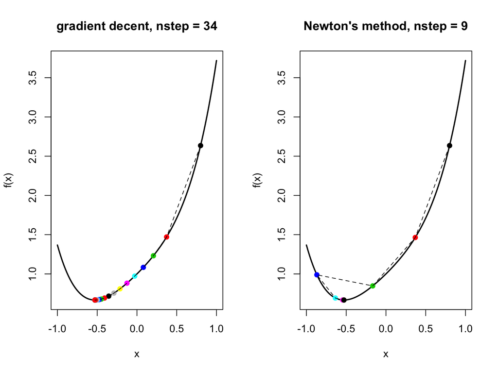

```r
f <- function(x) exp(x) + x^4 ## original function
par(mfrow=c(1,2))
title_grad <- paste("gradient decent, nstep =", length(trace_grad))
curve(f, from = -1, to = 1, lwd=2, main = title_grad)
points(trace_grad, f(trace_grad), col=seq_along(trace_grad), pch=19)
lines(trace_grad, f(trace_grad), lty = 2)

title_newton <- paste("Newton's method, nstep =", length(trace_newton))
curve(f, from = -1, to = 1, lwd=2, main = title_newton)
points(trace_newton, f(trace_newton), col=seq_along(trace_newton), pch=19)
lines(trace_newton, f(trace_newton), lty = 2)
```

# Alternative interpretation about Newton’s method

- Aternative interpretation of Newton’s step: we seek a direction $v$ so that $f'(x + v) = 0$.
- By Taylor expansion:
  $$0 = f'(x + v) \approx f'(x) + f''(x)v$$
- Solve for $v$, we have $v = -(f''(x))^{-1} f'(x)$

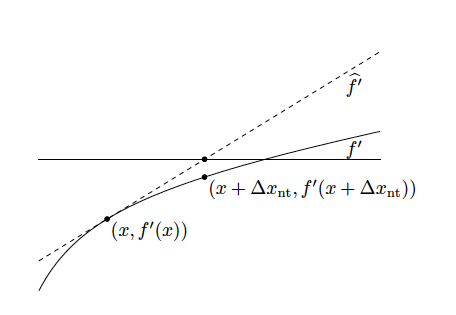

# Backtracking line search for Newton’s method

- Usually pure Newton’s method works very well (do not necessary need to use backtracking)
- We have seen pure Newton’s method, which need not to decent at all iterations.
- In practice, we can use Newton’s method with backtracking search, which repeats
  $$x^{(k)} = x^{(k - 1)} - t(f''(x^{(k-1)}))^{-1}f'(x^{(k-1)})$$
- Note that the pure Newton’s method uses $t = 1$
- Algorithm:
  - Fix parameter $0 < \beta < 1$ and $0 < \alpha \le 1/2$
  - At each Newton’s iteration $x$, start with $t=1$, while
    $$f(x + t \Delta x) > f(x) + \alpha t \times f'(x) \Delta x$$
    Update $t = \beta t$
  - In other word (set $\Delta x = - (f''(x))^{-1} f'(x)$), while
    $$f(x - t (f''(x))^{-1} f'(x)) > f(x) - \alpha t (f''(x))^{-1} (f'(x))^2$$
    Update $t = \beta t$

# Implementation of back-tracking for Newton’s method

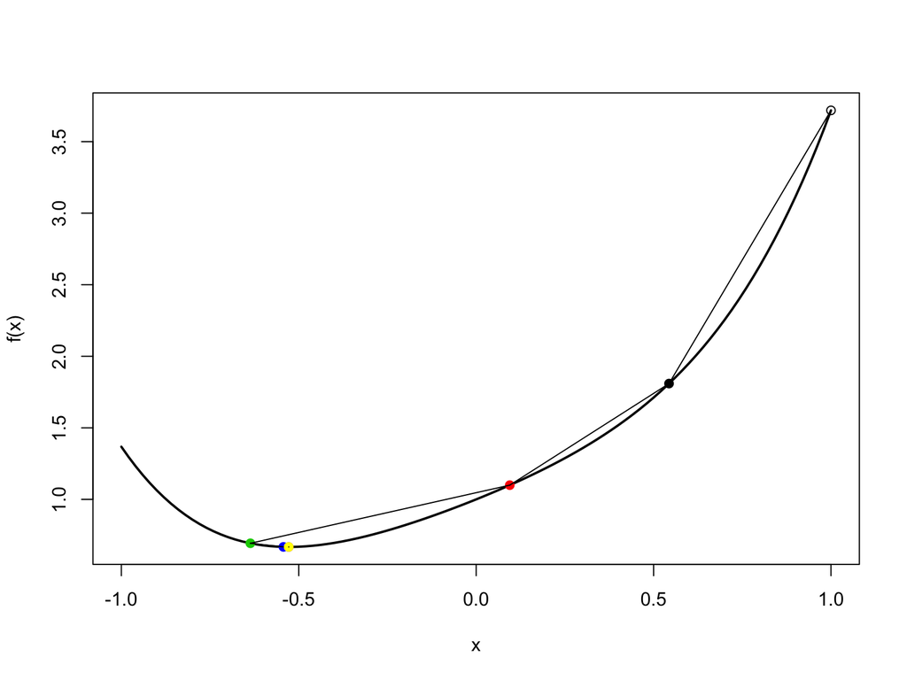

```r
f <- function(x) exp(x) + x^4 ## original function
g <- function(x) exp(x) + 4 * x^3 ## gradient function
h <- function(x) exp(x) + 12 * x^2 ## gradient function
curve(f, from = -1, to = 1, lwd=2) ## visualize the objective function

x <- x0 <- 1; x_old <- 0; t0 <- 1; k <- 0; error <- 1e-6; beta = 0.8; alpha <- 0.4
trace <- x
points(x0, f(x0), col=1, pch=1)

while(abs(x - x_old) > error & k < 30){
  k <- k + 1
  x_old <- x

  ## backtracking
  t <- t0
  while(f(x_old - t*g(x_old)/h(x_old)) > f(x_old) - alpha * t * g(x_old)^2/h(x_old)){
    t <- t * beta
  }

  x <- x_old - t*g(x_old)/h(x_old)
  trace <- c(trace, x) ## collecting results
  points(x, f(x), col=k, pch=19)
  segments(x0=x, y0 = f(x), x1 = x_old, y1 = f(x_old))
}
```

```r
print(trace)
```

```
## [1]  1.00000000  0.54354171  0.09465801 -0.63631402 -0.54326938 -0.52858926
## [7] -0.52825205 -0.52825187
```

# Exercise (will be on HW), solve for logistic regression

```r
library(ElemStatLearn)
glm_binomial_logit <- glm(svi ~ lcavol, data = prostate,  family = binomial())
summary(glm_binomial_logit)
```

```
##
## Call:
## glm(formula = svi ~ lcavol, family = binomial(), data = prostate)
##
## Deviance Residuals:
##      Min        1Q    Median        3Q       Max
## -1.79924  -0.48354  -0.21025  -0.04274   2.32135
##
## Coefficients:
##             Estimate Std. Error z value Pr(>|z|)
## (Intercept)  -5.0296     1.0429  -4.823 1.42e-06 ***
## lcavol        1.9798     0.4543   4.358 1.31e-05 ***
## ---
## Signif. codes:  0 '***' 0.001 '**' 0.01 '*' 0.05 '.' 0.1 ' ' 1
##
## (Dispersion parameter for binomial family taken to be 1)
##
##     Null deviance: 101.35  on 96  degrees of freedom
## Residual deviance:  64.14  on 95  degrees of freedom
## AIC: 68.14
##
## Number of Fisher Scoring iterations: 6
```

- We set $\beta_0 = -5.0296$.
- Try to optimize $\beta_1$, the coefficient for lcavol using Newton’s method
- compare with gradient method

# Comparison between gradient decent and Newton’s method

| Method | Gradient decent | Newton’s method |
| --- | --- | --- |
| Order | First order method | Second Order method |
| Criterion | smooth $f$ | double smooth $f$ |
| Convergence (# iterations) | Slow | Fast |
| Iteration cost | cheap (compute gradient) | moderate to expensive (Compute Hessian) |

# Multivariate Case

- What if $\beta$ is not a scalar but instead a vector (i.e. $\beta \in \mathbb{R}^p$)?
- Will gradient decent still work?
  - Yes
- How to calculate the gradient (derivative) for multivariate case?
- Will Newton’s method still work?
  - Yes
- How to calculate the Hessian matrix for multivariate case?

# Gradient in multivariate case

- $\beta = (\beta_1, \beta_2, \ldots, \beta_p)^\top \in \mathbb{R}^p$ is a $p$-dimensional column vector
- $f(\beta) \in \mathbb{R}$ is a function which map $\mathbb{R}^p \rightarrow \mathbb{R}$
- Suppose $f(\beta)$ is differentiable with respect to $\beta$.

Then
$$\nabla_\beta f(\beta) = \frac{\partial f(\beta)}{\partial \beta}
= (\frac{\partial f(\beta)}{\partial \beta_1}, \frac{\partial f(\beta)}{\partial \beta_2}, \ldots,
\frac{\partial f(\beta)}{\partial \beta_p})^\top \in \mathbb{R}^p$$

- Example
  $$f(x,y) = 4x^2 + y^2 + 2xy - x - y$$
  - $\frac{\partial f}{\partial x} = 8x + 2y - 1$
  - $\frac{\partial f}{\partial y} = 2y +2x - 1$
  - $\nabla f = (\frac{\partial f}{\partial x}, \frac{\partial f}{\partial y})^\top = \binom{8x + 2y - 1}{2y +2x - 1} \in \mathbb{R}^2$

# Visualization of the example function

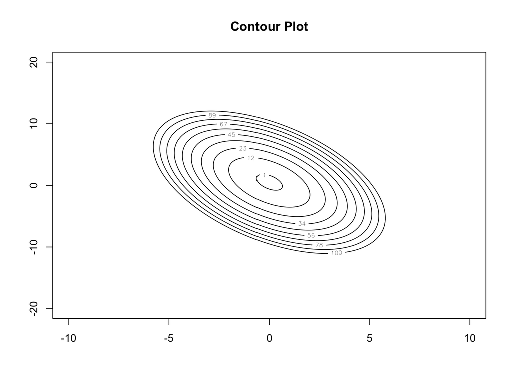

```r
f <- function(x,y){
  4 * x^2 + y^2 + 2 * x * y - x - y
}


xx <- yy <- seq(-20, 20, len=1000)
zz <- outer(xx, yy, f)
# Contour plots
contour(xx,yy,zz, xlim = c(-10,10), ylim = c(-20,20), nlevels = 10, levels = seq(1,100,length.out = 10), main="Contour Plot")
```

# Hessian in multivariate case

- $\beta = (\beta_1, \beta_2, \ldots, \beta_p)^\top \in \mathbb{R}^p$ is a $p$-dimensional column vector
- $f(\beta) \in \mathbb{R}$ is a function which map $\mathbb{R}^p \rightarrow \mathbb{R}$
- Suppose $f(\beta)$ is twice differentiable with respect to $\beta$.

Then
$$\nabla_\beta f(\beta) = \frac{\partial f(\beta)}{\partial \beta}
= (\frac{\partial f(\beta)}{\partial \beta_1}, \frac{\partial f(\beta)}{\partial \beta_2}, \ldots,
\frac{\partial f(\beta)}{\partial \beta_p})^\top \in \mathbb{R}^p$$

$$\Delta_\beta f(\beta) = \nabla^2_\beta f(\beta) = \nabla_\beta\frac{\partial f(\beta)}{\partial \beta}
= (\nabla_\beta \frac{\partial f(\beta)}{\partial \beta_1}, \nabla_\beta \frac{\partial f(\beta)}{\partial \beta_2}, \ldots,
\nabla_\beta \frac{\partial f(\beta)}{\partial \beta_p})^\top$$

$$\Delta_\beta f(\beta)
=
\begin{pmatrix}
\frac{\partial^2 f(\beta)}{\partial \beta_1^2} & \frac{\partial^2 f(\beta)}{\partial \beta_1 \partial \beta_2} & \ldots & \frac{\partial^2 f(\beta)}{\partial \beta_1 \partial\beta_p}\\
\frac{\partial^2 f(\beta)}{\partial \beta_2 \partial \beta_1 } & \frac{\partial^2 f(\beta)}{\partial \beta_2^2} & \ldots & \frac{\partial^2 f(\beta)}{\partial \beta_2 \partial \beta_p} \\
\ldots &\ldots &\ldots &\ldots\\
\frac{\partial^2 f(\beta)}{\partial \beta_p \partial \beta_1} & \frac{\partial^2 f(\beta)}{\partial \beta_p \partial \beta_2} & \ldots & \frac{\partial^2 f(\beta)}{\partial\beta_p^2}
\end{pmatrix}$$

# Hessian in multivariate case example

$$f(x,y) = 4x^2 + y^2 + 2xy - x - y$$

- Gradient
  - $\frac{\partial f}{\partial x} = 8x + 2y - 1$
  - $\frac{\partial f}{\partial y} = 2y +2x - 1$

$$\nabla f = (\frac{\partial f}{\partial x}, \frac{\partial f}{\partial y})^\top =
\binom{8x + 2y - 1}{2y +2x - 1} \in \mathbb{R}^2$$

- Hessian
  - $\frac{\partial^2 f}{\partial x^2} = 8$
  - $\frac{\partial^2 f}{\partial y^2} = 2$
  - $\frac{\partial^2 f}{\partial x \partial y} = 2$

$$\Delta f = \begin{pmatrix}
8 & 2 \\
2 & 2
\end{pmatrix}
\in \mathbb{R}^{2\times 2}$$

# Gradient decent for multivariate case

**Gradient decent**: choose initial $\beta^{(0)} \in \mathbb{R}^p$, repeat:
$$\beta^{(k)} = \beta^{(k - 1)} - t\times \nabla_\beta f(\beta^{(k - 1)}), k = 1,2,3,\ldots$$

- Until $\frac{\|\beta^{(k)} - \beta^{(k - 1)}\|_2}{\|\beta^{(k)} + \beta^{(k - 1)}\|_2} < \varepsilon$, (e.g. $\varepsilon = 10^{-6}$).
- $\nabla_\beta f(\beta^{(k - 1)})$ is the gradient (derivative of $f$) evaluated at $\beta^{(k - 1)}$.
- $t$ is a step size for gradient decent procedure.

# Gradient decent on our motivating example

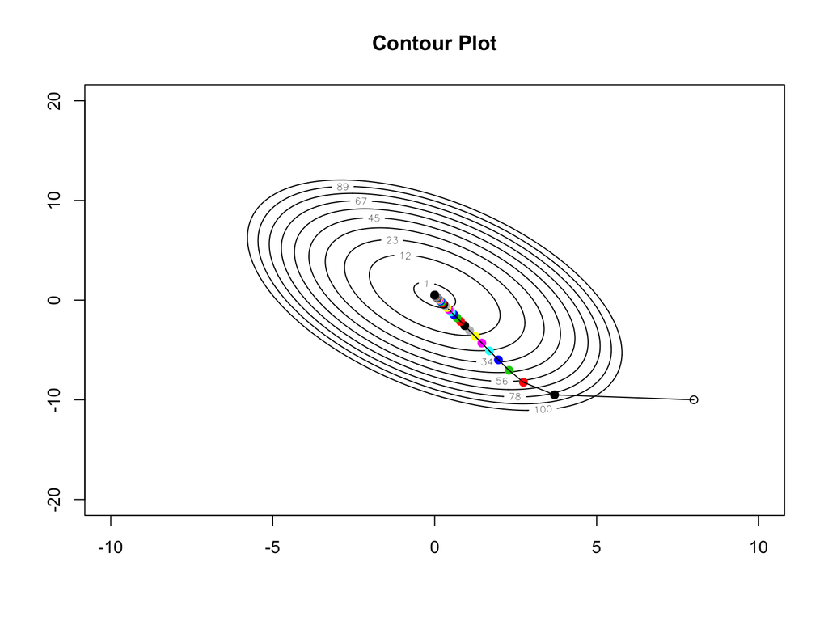

```r
f <- function(x,y){
  4 * x^2 + y^2 + 2 * x * y - x - y
}

g <- function(x,y){
  c(8*x + 2*y - 1, 2*y +2*x - 1)
}

xx <- yy <- seq(-20, 20, len=1000)
zz <- outer(xx, yy, f)
# Contour plots
contour(xx,yy,zz, xlim = c(-10,10), ylim = c(-20,20), nlevels = 10, levels = seq(1,100,length.out = 10), main="Contour Plot")


x <- x0 <- 8; x_old <- 0;
y <- y0 <- -10; y_old <- 0;
curXY <- c(x,y)
preXY <- c(x_old, y_old)
t <- 0.1; k <- 0; error <- 1e-6
trace <- list(curXY)
points(x0,y0, col=1, pch=1)

l2n <- function(avec){
  sqrt(sum(avec^2))
}
diffChange <- function(avec, bvec){
  deltaVec <- avec - bvec
  sumVec <- avec + bvec
  l2n(deltaVec)/l2n(sumVec)
}

while(diffChange(curXY, preXY) > error){
  k <- k + 1
  preXY <- curXY
  curXY <- preXY - t*g(preXY[1], preXY[2])
  trace <- c(trace, list(curXY)) ## collecting results
  points(curXY[1], curXY[2], col=k, pch=19)
  segments(curXY[1], curXY[2], preXY[1], preXY[2])
}
```

```r
print(k)
```

```
## [1] 97
```

# How to select step size $t$, backtracking line search

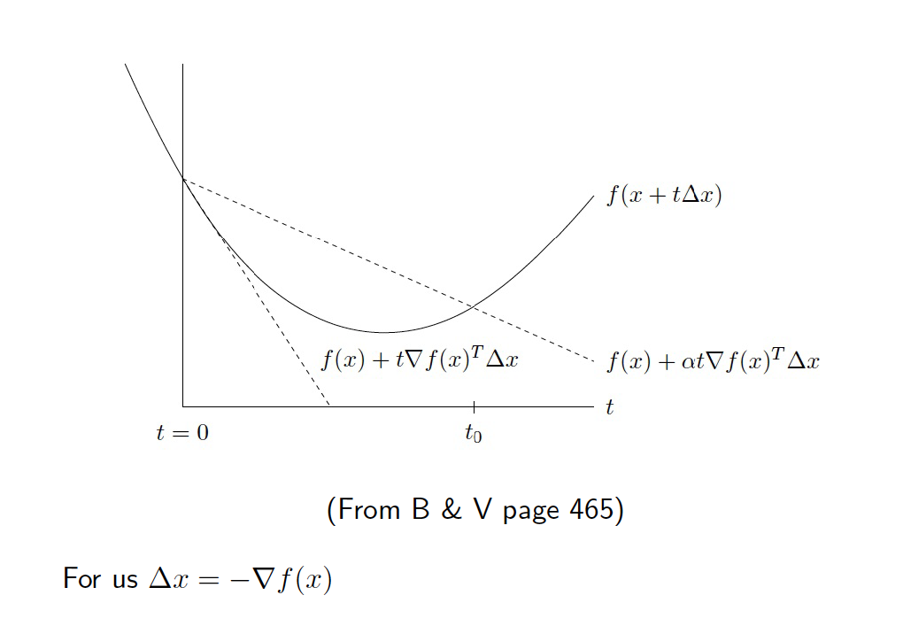

# How to select step size $t$, backtracking line search

- Linear approximation (first order Taylor expansion) at the current point $x$.
  $$f(x + t\Delta x) = f(x) + t\nabla f(x)^\top\Delta x$$
- Decrease the slope of the approximation by $\alpha$

$$f(x) + t\alpha \nabla f(x)^\top\Delta x$$

- A sufficient condition for a proposed $t$ to guarantee **decent** (decrease objective function):
  $$f(x + t\Delta x) < f(x) + t\alpha \nabla f(x)^\top\Delta x$$
- Plugin $\Delta x = -f'(x)$
  $$f(x - t\nabla f(x)) < f(x) - \alpha t \times \|(\nabla f(x)\|_2^2$$
- Algorithm:
  - Fix parameter $0 < \gamma < 1$ and $0 < \alpha \le 1/2$
  - At each gradient decent iteration, start with $t=1$, while
    $$f(\beta - t\times \nabla f(\beta)) > f(\beta) - \alpha t \times \|(\nabla f(\beta)\|_2^2$$
    Update $t = \gamma t$

# Implementation of back-tracking for gradient decent

- Minimize $f(x,y) = 4x^2 + y^2 + 2xy - x - y$
- gradient $\nabla f = \binom{8x + 2y - 1}{2y +2x - 1}$
- Initial point $x_0 = 8$; $y_0 = -10$
- initial step size $t_0 = 1$, $\alpha = 1/3$, $\gamma = 1/2$
  - At each step, start with $t = t_0$,
  - if $f(x - tg(x)) > f(x) - \alpha t \|g(x)\|_2^2$, set $t = \gamma t$
  - otherwise, use $t$ as step size

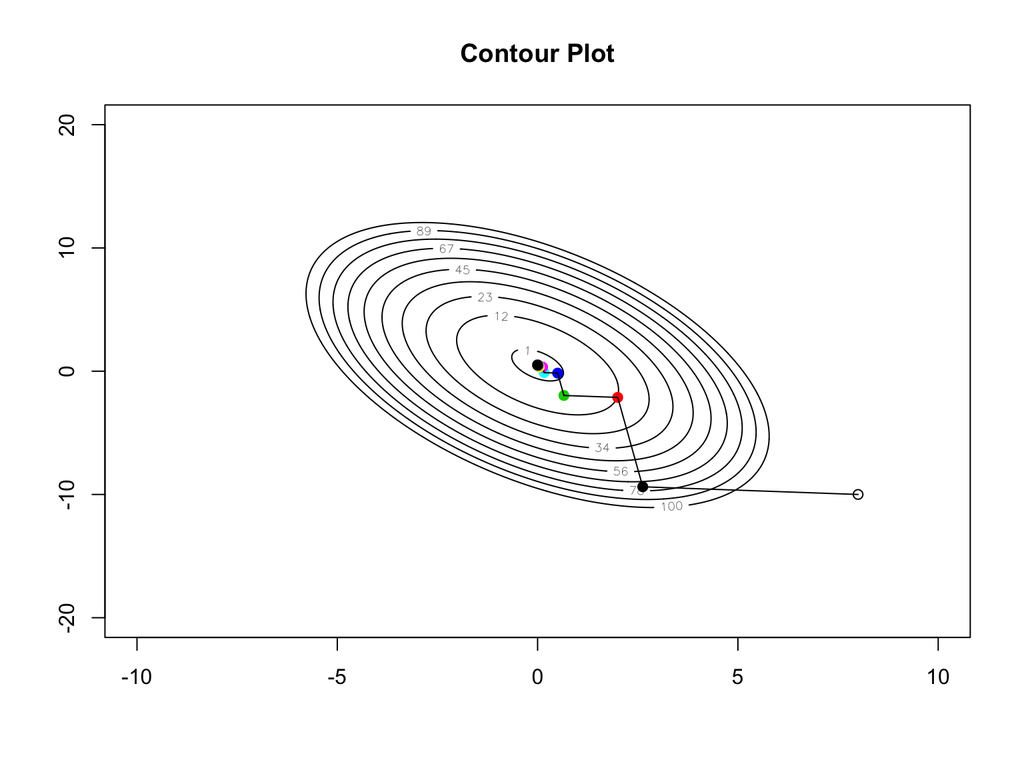

```r
f0 <- function(x,y){
  4 * x^2 + y^2 + 2 * x * y - x - y
}

f <- function(avec){
  x <- avec[1]
  y <- avec[2]
  4 * x^2 + y^2 + 2 * x * y - x - y
}

g <- function(avec){
  x <- avec[1]
  y <- avec[2]
  c(8*x + 2*y - 1, 2*y +2*x - 1)
}

x <- y <- seq(-20, 20, len=1000)
z <- outer(x, y, f0)
# Contour plots
contour(x,y,z, xlim = c(-10,10), ylim = c(-20,20), nlevels = 10, levels = seq(1,100,length.out = 10), main="Contour Plot")


x <- x0 <- 8; x_old <- 0;
y <- y0 <- -10; y_old <- 0;
curXY <- c(x,y)
preXY <- c(x_old, y_old)
t0 <- 1; k <- 0; error <- 1e-6
alpha = 1/3
beta = 1/2
trace <- list(curXY)
points(x0,y0, col=1, pch=1)

l2n <- function(avec){
  sqrt(sum(avec^2))
}
diffChange <- function(avec, bvec){
  deltaVec <- avec - bvec
  sumVec <- avec + bvec
  l2n(deltaVec)/l2n(sumVec)
}

while(diffChange(curXY, preXY) > error){
  k <- k + 1
  preXY <- curXY

  ## backtracking
  t <- t0
  while(f(preXY - t*g(preXY)) > f(preXY) - alpha * t * l2n(g(preXY))^2){
    t <- t * beta
  }

  curXY <- preXY - t*g(preXY)
  trace <- c(trace, list(curXY)) ## collecting results
  points(curXY[1], curXY[2], col=k, pch=19)
  segments(curXY[1], curXY[2], preXY[1], preXY[2])

}
```

```r
print(k)
```

```
## [1] 25
```

# Exercise, solve for logistic regression

```r
library(ElemStatLearn)
glm_binomial_logit <- glm(svi ~ lcavol, data = prostate,  family = binomial())
summary(glm_binomial_logit)
```

```
##
## Call:
## glm(formula = svi ~ lcavol, family = binomial(), data = prostate)
##
## Deviance Residuals:
##      Min        1Q    Median        3Q       Max
## -1.79924  -0.48354  -0.21025  -0.04274   2.32135
##
## Coefficients:
##             Estimate Std. Error z value Pr(>|z|)
## (Intercept)  -5.0296     1.0429  -4.823 1.42e-06 ***
## lcavol        1.9798     0.4543   4.358 1.31e-05 ***
## ---
## Signif. codes:  0 '***' 0.001 '**' 0.01 '*' 0.05 '.' 0.1 ' ' 1
##
## (Dispersion parameter for binomial family taken to be 1)
##
##     Null deviance: 101.35  on 96  degrees of freedom
## Residual deviance:  64.14  on 95  degrees of freedom
## AIC: 68.14
##
## Number of Fisher Scoring iterations: 6
```

- Optimize $\beta_1$, the coefficient for lcavol and the intercept $\beta_0$ simultaneously using gradient decent method.

# Newton’s method for multivariate case

- For unconstrained, smooth univariate convex optimization
  $$\min f(\beta)$$
  where $f$ is convex, twice differentiable, $\beta \in \mathbb{R}^p$, $f \in \mathbb{R}$. For **gradient descent**, start with initial value $\beta^{(0)}$ and repeat the following $(k = 1,2,3,\ldots)$ until converge
  $$\beta^{(k)} = \beta^{(k - 1)} - t_k \nabla f(\beta^{(k - 1)})$$
- For **Newton’s method**, start with initial value $\beta^{(0)}$ and repeat the following $(k = 1,2,3,\ldots)$ until converge
  $$\beta^{(k)} = \beta^{(k - 1)} - (\Delta f(\beta^{(k - 1)}))^{-1} \nabla f(\beta^{(k - 1)})$$
  Where $\Delta f(\beta^{(k - 1)}) \in \mathbb{R}^{p\times p}$ is the Hessian matrix of $f$ at $\beta^{(k - 1)}$.

# Implement multivariate Newton’s method

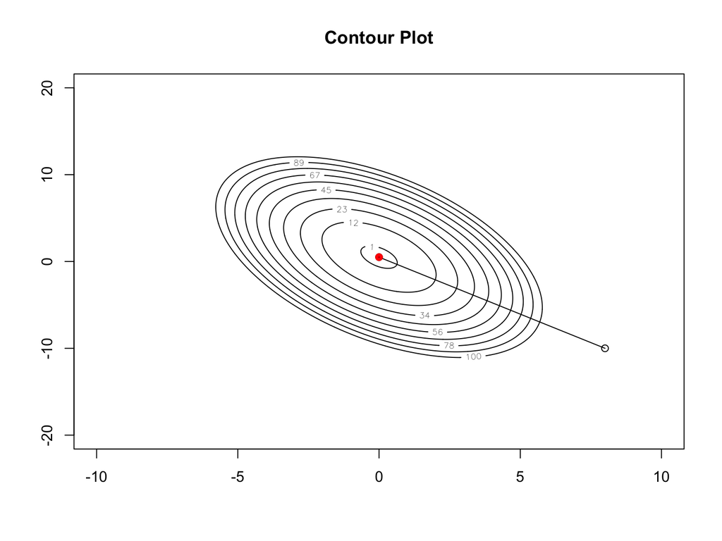

```r
f0 <- function(x,y){
  4 * x^2 + y^2 + 2 * x * y - x - y
}

f <- function(avec){
  x <- avec[1]
  y <- avec[2]
  4 * x^2 + y^2 + 2 * x * y - x - y
}

g <- function(avec){
  x <- avec[1]
  y <- avec[2]
  c(8*x + 2*y - 1, 2*y +2*x - 1)
}

h <- function(avec){
  x <- avec[1]
  y <- avec[2]
  res <- matrix(c(8,2,2,2),2,2)  ## Hessian function
  return(res)
}

x <- y <- seq(-20, 20, len=1000)
z <- outer(x, y, f0)
# Contour plots
contour(x,y,z, xlim = c(-10,10), ylim = c(-20,20), nlevels = 10, levels = seq(1,100,length.out = 10), main="Contour Plot")


x <- x0 <- 8; x_old <- 0;
y <- y0 <- -10; y_old <- 0;
curXY <- c(x,y)
preXY <- c(x_old, y_old)
t0 <- 1; k <- 0; error <- 1e-6
trace <- list(curXY)
points(x0,y0, col=1, pch=1)

l2n <- function(avec){
  sqrt(sum(avec^2))
}
diffChange <- function(avec, bvec){
  deltaVec <- avec - bvec
  sumVec <- avec + bvec
  l2n(deltaVec)/l2n(sumVec)
}

while(diffChange(curXY, preXY) > error){
  k <- k + 1
  preXY <- curXY

  curXY <- preXY - solve(h(curXY)) %*% g(preXY)
  trace <- c(trace, list(curXY)) ## collecting results
  points(curXY[1], curXY[2], col=k, pch=19)
  segments(curXY[1], curXY[2], preXY[1], preXY[2])
}
```

```r
k ## why k is only 2?
```

```
## [1] 2
```

# Exercise

$$f(x,y) = \exp(xy) + y^2 + x^4$$

What are the x and y such that $f(x,y)$ is minimized?

- Use Newton’s method to solve this problem

# Backtracking line search for Newton’s method

- Usually pure Newton’s method works very well (do not necessary need to use backtracking)
- We have seen pure Newton’s method, which need not to decent at all iterations.
- In practice, we can use Newton’s method with backtracking search, which repeats
  $$\beta^{(k)} = \beta^{(k - 1)} - t (\Delta f(\beta^{(k - 1)}))^{-1} \nabla f(\beta^{(k - 1)})$$
- Note that the pure Newton’s method uses $t = 1$
- Algorithm:
  - Fix parameter $0 < \gamma < 1$ and $0 < \alpha \le 1/2$
  - At each Newton’s iteration $x$, start with $t=1$, while
    $$f(\beta + t \Delta \beta) > f(\beta) + \alpha t \times \nabla f(\beta)^\top \Delta \beta$$
    Update $t = \gamma t$
  - In other word (set $\Delta \beta = - (\Delta f(\beta))^{-1} \nabla f(\beta)$), while
    $$f(\beta - t \Delta f(\beta)^{-1} \nabla f(\beta))
    > f(\beta) - \alpha t (\nabla f(\beta))^\top (\Delta f(\beta))^{-1} \nabla f(\beta)$$
    Update $t = \gamma t$

# Exercise, solve for logistic regression

```r
library(ElemStatLearn)
glm_binomial_logit <- glm(svi ~ lcavol, data = prostate,  family = binomial())
summary(glm_binomial_logit)
```

```
##
## Call:
## glm(formula = svi ~ lcavol, family = binomial(), data = prostate)
##
## Deviance Residuals:
##      Min        1Q    Median        3Q       Max
## -1.79924  -0.48354  -0.21025  -0.04274   2.32135
##
## Coefficients:
##             Estimate Std. Error z value Pr(>|z|)
## (Intercept)  -5.0296     1.0429  -4.823 1.42e-06 ***
## lcavol        1.9798     0.4543   4.358 1.31e-05 ***
## ---
## Signif. codes:  0 '***' 0.001 '**' 0.01 '*' 0.05 '.' 0.1 ' ' 1
##
## (Dispersion parameter for binomial family taken to be 1)
##
##     Null deviance: 101.35  on 96  degrees of freedom
## Residual deviance:  64.14  on 95  degrees of freedom
## AIC: 68.14
##
## Number of Fisher Scoring iterations: 6
```

- Optimize $\beta_1$, the coefficient for lcavol and the intercept $\beta_0$ simultaneously using Newton’s method.

# Coordinate decent

- Suppose $\beta \in \mathbb{R}^P$ and $f(\beta)$ is a mapping from $\mathbb{R}^P$ to $R$.
- We can use **coordinate descent** to find a minimizer.
- Start with an initial guess $\beta^{(0)} = (\beta^{(0)}_1, \beta^{(0)}_2, \ldots, \beta^{(0)}_p)^\top$ and repeat the following:
  - $\beta_1^{(k)} = \arg \min_{\beta_1} f(\beta_1, \beta_2^{(k-1)}, \beta_3^{(k-1)}, \ldots, \beta_p^{(k-1)})$
  - $\beta_2^{(k)} = \arg \min_{\beta_2} f(\beta_1^{(k)}, \beta_2, \beta_3^{(k-1)}, \ldots, \beta_p^{(k-1)})$
  - $\beta_3^{(k)} = \arg \min_{\beta_3} f(\beta_1^{(k)}, \beta_2^{(k)}, \beta_3, \ldots, \beta_p^{(k-1)})$
  - $\ldots$
  - $\beta_p^{(k)} = \arg \min_{\beta_p} f(\beta_1^{(k)}, \beta_2^{(k)}, \beta_3^{(k)}, \ldots, \beta_p)$
- Continue with $k=1,2,3,\ldots$ until converge.
  - Note that after $\beta_j^{(k)}$ has been updated, we use the new value for future update.

# Example on linear regression

- Consider linear regression problem:

$$\min_{\beta \in \mathbb{R}^p} f(\beta) = \min_{\beta \in \mathbb{R}^p} \frac{1}{2} \|y - X\beta\|_2^2$$
where $y \in \mathbb{R}^n$ and $X \in \mathbb{R}^{n \times p}$ with columns $X_1$ (intercept), $X_2$, $\ldots$, $X_p$.

- Minimizing over $\beta_j$ while fixing all $\beta_i$, $i \ne j$:
  $$0 = \frac{\partial f(\beta)}{\partial \beta_j} = X_j^\top (X\beta - y) = X_j^\top (X_j\beta_j + X_{-j}\beta_{-j} - y)$$
- We can solve for the coordinate descent updating rule:

$$\beta_j = \frac{X_j^\top (y - X_{-j}\beta_{-j})}{X_j^\top X_j}$$

# implement coordinate decent using prostate cancer data

```r
library(ElemStatLearn)

y <- prostate$lcavol
x0 <- prostate[,-match(c("lcavol", "train"), colnames(prostate))]
x <- cbind(1, as.matrix(x0))

beta <- rep(0,ncol(x))
beta_old <- rnorm(ncol(x))

error <- 1e-6
k <- 0
while(diffChange(beta, beta_old) > error){
  k <- k + 1
  beta_old <- beta
  for(j in 1:length(beta)){
    xj <- x[,j]
    xj_else <- x[,-j]
    beta_j_else <- as.matrix(beta[-j])
    beta[j] <- t(xj) %*% (y - xj_else %*% beta_j_else) / sum(xj^2)
  }
}

print(beta)
```

```
## [1] -2.419610178 -0.025954949  0.022114840 -0.093134994 -0.152983715
## [6]  0.367195579  0.197095411 -0.007114941  0.565822653
```

```r
## compare with lm
lm(lcavol ~ . - train, data=prostate)
```

```
##
## Call:
## lm(formula = lcavol ~ . - train, data = prostate)
##
## Coefficients:
## (Intercept)      lweight          age         lbph          svi
##   -2.420613    -0.025925     0.022113    -0.093138    -0.152966
##         lcp      gleason        pgg45         lpsa
##    0.367180     0.197249    -0.007117     0.565826
```

# Reference

http://www.stat.cmu.edu/~ryantibs/convexopt/